# ANCOVA in Reading Regular Correct Words (Reading Regular Correct Words)

Geiser C. Challco geiser@alumni.usp.br

- Setting Initial Variables
- Descriptive Statistics of Initial Data
- ANCOVA and Pairwise for one factor: **grupo**
  - Without remove non-normal data
  - Computing ANCOVA and PairWise After removing non-normal data (OK)
    - Plots for ancova
    - Checking linearity assumption
    - Checking normality and homogeneity
- ANCOVA and Pairwise for two factors **grupo:genero**
  - Without remove non-normal data
  - Computing ANCOVA and PairWise After removing non-normal data (OK)
    - Plots for ancova
    - Checking linearity assumption
    - Checking normality and homogeneity
- ANCOVA and Pairwise for two factors **grupo:zona.participante**
  - Without remove non-normal data
  - Computing ANCOVA and PairWise After removing non-normal data (OK)
    - Plots for ancova
    - Checking linearity assumption
    - Checking normality and homogeneity
- ANCOVA and Pairwise for two factors **grupo:zona.escola**
  - Without remove non-normal data
  - Computing ANCOVA and PairWise After removing non-normal data (OK)
    - Plots for ancova
    - Checking linearity assumption
    - Checking normality and homogeneity
- ANCOVA and Pairwise for two factors **grupo:score.CR.quintile**
  - Without remove non-normal data
  - Computing ANCOVA and PairWise After removing non-normal data (OK)
    - Plots for ancova
    - Checking linearity assumption
    - Checking normality and homogeneity
- Summary of Results
  - Descriptive Statistics
  - ANCOVA Table Comparison
  - PairWise Table Comparison
  - EMMS Table Comparison

**NOTE**:

- Teste ANCOVA para determinar se houve diferenças significativas no Reading Regular Correct Words (medido usando pre- e pos-testes).
- ANCOVA test to determine whether there were significant differences in Reading Regular Correct Words (measured using pre- and post-tests).

# Setting Initial Variables

```r
dv = "score.CR"
dv.pos = "score.CR.pos"
dv.pre = "score.CR.pre"

fatores2 <- c("genero","zona.participante","zona.escola","score.CR.quintile")
lfatores2 <- as.list(fatores2)
names(lfatores2) <- fatores2

fatores1 <- c("grupo", fatores2)
lfatores1 <- as.list(fatores1)
names(lfatores1) <- fatores1

lfatores <- c(lfatores1)

color <- list()
color[["prepost"]] = c("#ffee65","#f28e2B")
color[["grupo"]] = c("#bcbd22","#008000")
color[["genero"]] = c("#FF007F","#4D4DFF")
color[["zona.escola"]] = c("#AA00FF","#00CCCC")
color[["zona.participante"]] = c("#AA00FF","#00CCCC")

level <- list()
level[["grupo"]] = c("Controle","Experimental")
level[["genero"]] = c("F","M")
level[["zona.escola"]] = c("Rural","Urbana")
level[["zona.participante"]] = c("Rural","Urbana")

# ..

ymin <- 0
ymax <- 0

ymin.ci <- 0
ymax.ci <- 0


color[["grupo:genero"]] = c(
  "Controle:F"="#ff99cb", "Controle:M"="#b7b7ff",
  "Experimental:F"="#FF007F", "Experimental:M"="#4D4DFF",
  "Controle.F"="#ff99cb", "Controle.M"="#b7b7ff",
  "Experimental.F"="#FF007F", "Experimental.M"="#4D4DFF"
)
color[["grupo:zona.escola"]] = c(
  "Controle:Rural"="#b2efef","Controle:Urbana"="#e5b2ff",
  "Experimental:Rural"="#00CCCC", "Experimental:Urbana"="#AA00FF",
  "Controle.Rural"="#b2efef","Controle.Urbana"="#e5b2ff",
  "Experimental.Rural"="#00CCCC", "Experimental.Urbana"="#AA00FF"
)
color[["grupo:zona.participante"]] = c(
  "Controle:Rural"="#b2efef","Controle:Urbana"="#e5b2ff",
  "Experimental:Rural"="#00CCCC", "Experimental:Urbana"="#AA00FF",
  "Controle.Rural"="#b2efef","Controle.Urbana"="#e5b2ff",
  "Experimental.Rural"="#00CCCC", "Experimental.Urbana"="#AA00FF"
)

for (coln in c(
  "palavras.lidas","score.compreensao","tri.compreensao",
  "score.vocab","tri.vocab",
  "score.vocab.ensinado","tri.vocab.ensinado","score.vocab.nao.ensinado","tri.vocab.nao.ensinado",
  "score.CLPP","tri.CLPP","score.CR","tri.CR",
  "score.CI","tri.CI","score.TV","tri.TV","score.TF","tri.TF","score.TO","tri.TO")) {
  color[[paste0(coln,".quintile")]] = c("#BF0040","#FF0000","#800080","#0000FF","#4000BF")
  level[[paste0(coln,".quintile")]] = c("1st quintile","2nd quintile","3rd quintile","4th quintile","5th quintile")
  color[[paste0("grupo:",coln,".quintile")]] = c(
    "Experimental.1st quintile"="#BF0040", "Controle.1st quintile"="#d8668c",
    "Experimental.2nd quintile"="#FF0000", "Controle.2nd quintile"="#ff7f7f",
    "Experimental.3rd quintile"="#8fce00", "Controle.3rd quintile"="#ddf0b2",
    "Experimental.4th quintile"="#0000FF", "Controle.4th quintile"="#b2b2ff",
    "Experimental.5th quintile"="#4000BF", "Controle.5th quintile"="#b299e5",

    "Experimental:1st quintile"="#BF0040", "Controle:1st quintile"="#d8668c",
    "Experimental:2nd quintile"="#FF0000", "Controle:2nd quintile"="#ff7f7f",
    "Experimental:3rd quintile"="#8fce00", "Controle:3rd quintile"="#ddf0b2",
    "Experimental:4th quintile"="#0000FF", "Controle:4th quintile"="#b2b2ff",
    "Experimental:5th quintile"="#4000BF", "Controle:5th quintile"="#b299e5")
}


gdat <- read_excel("../data/data.xlsx", sheet = "leitura.wg.wo.st")



dat <- gdat
dat$grupo <- factor(dat[["grupo"]], level[["grupo"]])
for (coln in c(names(lfatores))) {
  dat[[coln]] <- factor(dat[[coln]], level[[coln]][level[[coln]] %in% unique(dat[[coln]])])
}
dat <- dat[which(!is.na(dat[[dv.pre]]) & !is.na(dat[[dv.pos]])),]
dat <- dat[,c("id",names(lfatores),dv.pre,dv.pos)]

dat.long <- rbind(dat, dat)
dat.long$time <- c(rep("pre", nrow(dat)), rep("pos", nrow(dat)))
dat.long$time <- factor(dat.long$time, c("pre","pos"))
dat.long[[dv]] <- c(dat[[dv.pre]], dat[[dv.pos]])


for (f in c("grupo", names(lfatores))) {
  if (is.null(color[[f]]) && length(unique(dat[[f]])) > 0)
      color[[f]] <- distinctColorPalette(length(unique(dat[[f]])))
}
for (f in c(fatores2)) {
  if (is.null(color[[paste0("grupo:",f)]]) && length(unique(dat[[f]])) > 0)
    color[[paste0("grupo:",f)]] <- distinctColorPalette(length(unique(dat[["grupo"]]))*length(unique(dat[[f]])))
}

ldat <- list()
laov <- list()
lpwc <- list()
lemms <- list()
```

# Descriptive Statistics of Initial Data

```r
df <- get.descriptives(dat, c(dv.pre, dv.pos), c("grupo"),
                       include.global = T, symmetry.test = T, normality.test = F)
df <- plyr::rbind.fill(
  df, do.call(plyr::rbind.fill, lapply(lfatores2, FUN = function(f) {
    if (nrow(dat) > 0 && sum(!is.na(unique(dat[[f]]))) > 1)
      get.descriptives(dat, c(dv.pre,dv.pos), c("grupo", f),
                       symmetry.test = T, normality.test = F)
    }))
)
df <- df[,c(fatores1[fatores1 %in% colnames(df)],"variable",
            colnames(df)[!colnames(df) %in% c(fatores1,"variable")])]
```

| grupo | genero | zona.participante | zona.escola | score.CR.quintile | variable | n | mean | median | min | max | sd | se | ci | iqr | symmetry | skewness | kurtosis |
| --- | --- | --- | --- | --- | --- | --- | --- | --- | --- | --- | --- | --- | --- | --- | --- | --- | --- |
| Controle |  |  |  |  | score.CR.pre | 176 | 13.949 | 15.0 | 0 | 20 | 4.435 | 0.334 | 0.660 | 5.00 | NO | -1.570 | 2.577 |
| Experimental |  |  |  |  | score.CR.pre | 135 | 15.119 | 16.0 | 0 | 20 | 4.141 | 0.356 | 0.705 | 4.00 | NO | -1.799 | 3.360 |
|  |  |  |  |  | score.CR.pre | 311 | 14.457 | 16.0 | 0 | 20 | 4.342 | 0.246 | 0.484 | 4.00 | NO | -1.650 | 2.853 |
| Controle |  |  |  |  | score.CR.pos | 176 | 13.131 | 15.0 | 0 | 20 | 5.968 | 0.450 | 0.888 | 6.00 | NO | -1.181 | 0.247 |
| Experimental |  |  |  |  | score.CR.pos | 135 | 13.837 | 16.0 | 0 | 20 | 5.647 | 0.486 | 0.961 | 6.00 | NO | -1.442 | 1.068 |
|  |  |  |  |  | score.CR.pos | 311 | 13.437 | 15.0 | 0 | 20 | 5.832 | 0.331 | 0.651 | 7.00 | NO | -1.294 | 0.583 |
| Controle | F |  |  |  | score.CR.pre | 87 | 14.471 | 16.0 | 0 | 19 | 4.350 | 0.466 | 0.927 | 4.50 | NO | -1.719 | 3.144 |
| Controle | M |  |  |  | score.CR.pre | 89 | 13.438 | 15.0 | 0 | 20 | 4.482 | 0.475 | 0.944 | 4.00 | NO | -1.452 | 2.148 |
| Experimental | F |  |  |  | score.CR.pre | 59 | 16.068 | 17.0 | 0 | 20 | 3.413 | 0.444 | 0.890 | 3.00 | NO | -2.335 | 7.063 |
| Experimental | M |  |  |  | score.CR.pre | 75 | 14.333 | 16.0 | 0 | 20 | 4.524 | 0.522 | 1.041 | 5.50 | NO | -1.463 | 1.820 |
| Experimental |  |  |  |  | score.CR.pre | 1 | 18.000 | 18.0 | 18 | 18 |  |  |  | 0.00 | few data | 0.000 | 0.000 |
| Controle | F |  |  |  | score.CR.pos | 87 | 14.184 | 16.0 | 0 | 20 | 5.290 | 0.567 | 1.128 | 5.00 | NO | -1.540 | 1.624 |
| Controle | M |  |  |  | score.CR.pos | 89 | 12.101 | 15.0 | 0 | 19 | 6.428 | 0.681 | 1.354 | 8.00 | NO | -0.878 | -0.573 |
| Experimental | F |  |  |  | score.CR.pos | 59 | 14.746 | 17.0 | 0 | 20 | 5.463 | 0.711 | 1.424 | 4.00 | NO | -1.752 | 2.022 |
| Experimental | M |  |  |  | score.CR.pos | 75 | 13.307 | 15.0 | 0 | 19 | 5.551 | 0.641 | 1.277 | 6.00 | NO | -1.299 | 0.807 |
| Experimental |  |  |  |  | score.CR.pos | 1 | 0.000 | 0.0 | 0 | 0 |  |  |  | 0.00 | few data | 0.000 | 0.000 |
| Controle |  | Rural |  |  | score.CR.pre | 56 | 14.000 | 15.0 | 0 | 20 | 4.125 | 0.551 | 1.105 | 5.00 | NO | -1.399 | 2.430 |
| Controle |  | Urbana |  |  | score.CR.pre | 77 | 13.948 | 15.0 | 0 | 20 | 4.724 | 0.538 | 1.072 | 5.00 | NO | -1.603 | 2.349 |
| Controle |  |  |  |  | score.CR.pre | 43 | 13.884 | 15.0 | 0 | 19 | 4.393 | 0.670 | 1.352 | 4.00 | NO | -1.529 | 2.393 |
| Experimental |  | Rural |  |  | score.CR.pre | 52 | 15.231 | 16.0 | 6 | 20 | 3.473 | 0.482 | 0.967 | 4.00 | NO | -0.956 | 0.037 |
| Experimental |  | Urbana |  |  | score.CR.pre | 49 | 14.265 | 17.0 | 0 | 19 | 5.484 | 0.783 | 1.575 | 6.00 | NO | -1.457 | 1.090 |
| Experimental |  |  |  |  | score.CR.pre | 34 | 16.176 | 16.5 | 10 | 19 | 2.236 | 0.383 | 0.780 | 3.00 | NO | -1.146 | 0.954 |
| Controle |  | Rural |  |  | score.CR.pos | 56 | 14.161 | 15.0 | 0 | 20 | 4.600 | 0.615 | 1.232 | 5.25 | NO | -1.543 | 2.327 |
| Controle |  | Urbana |  |  | score.CR.pos | 77 | 12.935 | 16.0 | 0 | 20 | 6.319 | 0.720 | 1.434 | 6.00 | NO | -1.074 | -0.187 |
| Controle |  |  |  |  | score.CR.pos | 43 | 12.140 | 15.0 | 0 | 20 | 6.781 | 1.034 | 2.087 | 7.50 | NO | -0.822 | -0.785 |
| Experimental |  | Rural |  |  | score.CR.pos | 52 | 15.288 | 16.0 | 7 | 19 | 3.327 | 0.461 | 0.926 | 6.00 | NO | -0.705 | -0.670 |
| Experimental |  | Urbana |  |  | score.CR.pos | 49 | 13.245 | 15.0 | 0 | 19 | 5.988 | 0.855 | 1.720 | 5.00 | NO | -1.251 | 0.318 |
| Experimental |  |  |  |  | score.CR.pos | 34 | 12.471 | 15.5 | 0 | 20 | 7.378 | 1.265 | 2.574 | 8.75 | NO | -0.925 | -0.908 |
| Controle |  |  | Rural |  | score.CR.pre | 58 | 13.759 | 15.0 | 0 | 20 | 4.758 | 0.625 | 1.251 | 6.00 | NO | -1.252 | 1.212 |
| Controle |  |  | Urbana |  | score.CR.pre | 118 | 14.042 | 15.0 | 0 | 20 | 4.286 | 0.395 | 0.781 | 4.00 | NO | -1.738 | 3.390 |
| Experimental |  |  | Rural |  | score.CR.pre | 40 | 15.300 | 16.0 | 0 | 20 | 4.134 | 0.654 | 1.322 | 3.25 | NO | -1.805 | 3.290 |
| Experimental |  |  | Urbana |  | score.CR.pre | 95 | 15.042 | 16.0 | 0 | 20 | 4.164 | 0.427 | 0.848 | 4.00 | NO | -1.769 | 3.264 |
| Controle |  |  | Rural |  | score.CR.pos | 58 | 14.293 | 16.0 | 0 | 20 | 5.560 | 0.730 | 1.462 | 4.75 | NO | -1.509 | 1.253 |
| Controle |  |  | Urbana |  | score.CR.pos | 118 | 12.559 | 15.0 | 0 | 20 | 6.101 | 0.562 | 1.112 | 7.00 | NO | -1.042 | -0.109 |
| Experimental |  |  | Rural |  | score.CR.pos | 40 | 15.650 | 16.0 | 0 | 20 | 3.759 | 0.594 | 1.202 | 3.25 | NO | -2.012 | 5.379 |
| Experimental |  |  | Urbana |  | score.CR.pos | 95 | 13.074 | 15.0 | 0 | 19 | 6.132 | 0.629 | 1.249 | 7.00 | NO | -1.181 | 0.125 |
| Controle |  |  |  | 1st quintile | score.CR.pre | 9 | 0.000 | 0.0 | 0 | 0 | 0.000 | 0.000 | 0.000 | 0.00 | few data | 0.000 | 0.000 |
| Controle |  |  |  | 2nd quintile | score.CR.pre | 11 | 7.727 | 8.0 | 6 | 9 | 1.009 | 0.304 | 0.678 | 1.50 | YES | -0.039 | -1.430 |
| Controle |  |  |  | 3rd quintile | score.CR.pre | 26 | 11.000 | 11.0 | 10 | 12 | 0.849 | 0.166 | 0.343 | 2.00 | few data | 0.000 | 0.000 |
| Controle |  |  |  | 4th quintile | score.CR.pre | 75 | 14.680 | 15.0 | 13 | 16 | 1.080 | 0.125 | 0.248 | 2.00 | YES | -0.240 | -1.244 |
| Controle |  |  |  | 5th quintile | score.CR.pre | 55 | 17.873 | 18.0 | 17 | 20 | 0.840 | 0.113 | 0.227 | 1.00 | NO | 0.603 | -0.470 |
| Experimental |  |  |  | 1st quintile | score.CR.pre | 4 | 0.000 | 0.0 | 0 | 0 | 0.000 | 0.000 | 0.000 | 0.00 | few data | 0.000 | 0.000 |
| Experimental |  |  |  | 2nd quintile | score.CR.pre | 11 | 8.000 | 8.0 | 6 | 9 | 1.095 | 0.330 | 0.736 | 2.00 | YES | -0.415 | -1.485 |
| Experimental |  |  |  | 3rd quintile | score.CR.pre | 11 | 10.727 | 10.0 | 10 | 12 | 0.905 | 0.273 | 0.608 | 1.50 | few data | 0.000 | 0.000 |
| Experimental |  |  |  | 4th quintile | score.CR.pre | 43 | 15.163 | 15.0 | 13 | 16 | 0.843 | 0.129 | 0.259 | 1.00 | NO | -0.534 | -0.829 |
| Experimental |  |  |  | 5th quintile | score.CR.pre | 66 | 17.924 | 18.0 | 17 | 20 | 0.829 | 0.102 | 0.204 | 1.00 | YES | 0.457 | -0.664 |
| Controle |  |  |  | 1st quintile | score.CR.pos | 9 | 9.333 | 10.0 | 0 | 18 | 8.367 | 2.789 | 6.431 | 18.00 | YES | -0.065 | -2.037 |
| Controle |  |  |  | 2nd quintile | score.CR.pos | 11 | 10.636 | 13.0 | 0 | 16 | 6.021 | 1.815 | 4.045 | 7.00 | NO | -0.774 | -1.010 |
| Controle |  |  |  | 3rd quintile | score.CR.pos | 26 | 12.500 | 13.5 | 0 | 18 | 4.420 | 0.867 | 1.785 | 4.75 | NO | -0.835 | 0.390 |
| Controle |  |  |  | 4th quintile | score.CR.pos | 75 | 12.627 | 15.0 | 0 | 19 | 5.579 | 0.644 | 1.284 | 5.50 | NO | -1.222 | 0.439 |
| Controle |  |  |  | 5th quintile | score.CR.pos | 55 | 15.236 | 17.0 | 0 | 20 | 6.158 | 0.830 | 1.665 | 3.50 | NO | -1.828 | 1.842 |
| Experimental |  |  |  | 1st quintile | score.CR.pos | 4 | 7.250 | 6.5 | 0 | 16 | 8.461 | 4.230 | 13.463 | 13.75 | few data | 0.000 | 0.000 |
| Experimental |  |  |  | 2nd quintile | score.CR.pos | 11 | 12.273 | 12.0 | 7 | 17 | 2.970 | 0.895 | 1.995 | 3.50 | YES | -0.095 | -1.097 |
| Experimental |  |  |  | 3rd quintile | score.CR.pos | 11 | 12.273 | 12.0 | 0 | 18 | 4.777 | 1.440 | 3.209 | 4.00 | NO | -1.254 | 1.273 |
| Experimental |  |  |  | 4th quintile | score.CR.pos | 43 | 13.163 | 15.0 | 0 | 19 | 5.446 | 0.831 | 1.676 | 6.00 | NO | -1.341 | 0.693 |
| Experimental |  |  |  | 5th quintile | score.CR.pos | 66 | 15.197 | 17.0 | 0 | 20 | 5.720 | 0.704 | 1.406 | 4.00 | NO | -1.915 | 2.394 |

# ANCOVA and Pairwise for one factor: **grupo**

## Without remove non-normal data

```r
pdat = remove_group_data(dat[!is.na(dat[["grupo"]]),], "score.CR.pos", "grupo")

pdat.long <- rbind(pdat[,c("id","grupo")], pdat[,c("id","grupo")])
pdat.long[["time"]] <- c(rep("pre", nrow(pdat)), rep("pos", nrow(pdat)))
pdat.long[["time"]] <- factor(pdat.long[["time"]], c("pre","pos"))
pdat.long[["score.CR"]] <- c(pdat[["score.CR.pre"]], pdat[["score.CR.pos"]])

aov = anova_test(pdat, score.CR.pos ~ score.CR.pre + grupo)
laov[["grupo"]] <- get_anova_table(aov)
```

```r
pwc <- emmeans_test(pdat, score.CR.pos ~ grupo, covariate = score.CR.pre,
                    p.adjust.method = "bonferroni")
```

```r
pwc.long <- emmeans_test(dplyr::group_by_at(pdat.long, "grupo"),
                          score.CR ~ time,
                          p.adjust.method = "bonferroni")
lpwc[["grupo"]] <- plyr::rbind.fill(pwc, pwc.long)
```

```r
ds <- get.descriptives(pdat, "score.CR.pos", "grupo", covar = "score.CR.pre")
ds <- merge(ds[ds$variable != "score.CR.pre",],
            ds[ds$variable == "score.CR.pre", !colnames(ds) %in% c("variable")],
            by = "grupo", all.x = T, suffixes = c("", ".score.CR.pre"))
ds <- merge(get_emmeans(pwc), ds, by = "grupo", suffixes = c(".emms", ""))
ds <- ds[,c("grupo","n","mean.score.CR.pre","se.score.CR.pre","mean","se",
            "emmean","se.emms","conf.low","conf.high")]

colnames(ds) <- c("grupo", "N", paste0(c("M","SE")," (pre)"),
                  paste0(c("M","SE"), " (unadj)"),
                  paste0(c("M", "SE"), " (adj)"), "conf.low", "conf.high")

lemms[["grupo"]] <- ds
```

## Computing ANCOVA and PairWise After removing non-normal data (OK)

```r
wdat = pdat

res = residuals(lm(score.CR.pos ~ score.CR.pre + grupo, data = wdat))
non.normal = getNonNormal(res, wdat$id, plimit = 0.05)

wdat = wdat[!wdat$id %in% non.normal,]

wdat.long <- rbind(wdat[,c("id","grupo")], wdat[,c("id","grupo")])
wdat.long[["time"]] <- c(rep("pre", nrow(wdat)), rep("pos", nrow(wdat)))
wdat.long[["time"]] <- factor(wdat.long[["time"]], c("pre","pos"))
wdat.long[["score.CR"]] <- c(wdat[["score.CR.pre"]], wdat[["score.CR.pos"]])

ldat[["grupo"]] = wdat

(non.normal)
```

```
##  [1] "P59"  "P231" "P190" "P202" "P169" "P46"  "P103" "P232" "P294" "P195" "P179" "P356" "P80"
## [14] "P117" "P17"  "P87"  "P20"  "P312" "P106" "P79"  "P83"  "P242" "P198" "P94"  "P12"  "P282"
## [27] "P5"   "P314" "P305" "P68"  "P128" "P300" "P226" "P214" "P35"  "P75"  "P119" "P286" "P330"
## [40] "P186" "P229" "P307" "P364" "P281" "P22"  "P370" "P274" "P16"  "P121" "P308" "P118" "P131"
## [53] "P173" "P216" "P127" "P205" "P283" "P289" "P332" "P84"  "P167" "P146" "P297" "P306" "P15"
## [66] "P165" "P291" "P66"  "P293" "P365" "P288" "P151" "P89"  "P150" "P136" "P44"  "P174" "P320"
## [79] "P298" "P213" "P362" "P296" "P126" "P207" "P358" "P98"  "P137" "P116" "P135" "P110" "P328"
```

```r
aov = anova_test(wdat, score.CR.pos ~ score.CR.pre + grupo)
laov[["grupo"]] <- merge(get_anova_table(aov), laov[["grupo"]],
                            by="Effect", suffixes = c("","'"))

(df = get_anova_table(aov))
```

```
## ANOVA Table (type II tests)
##
##         Effect DFn DFd      F        p p<.05   ges
## 1 score.CR.pre   1 217 98.022 2.62e-19     * 0.311
## 2        grupo   1 217  0.463 4.97e-01       0.002
```

| Effect | DFn | DFd | F | p | p<.05 | ges |
| --- | --- | --- | --- | --- | --- | --- |
| score.CR.pre | 1 | 217 | 98.022 | 0.000 | * | 0.311 |
| grupo | 1 | 217 | 0.463 | 0.497 |  | 0.002 |

```r
pwc <- emmeans_test(wdat, score.CR.pos ~ grupo, covariate = score.CR.pre,
                    p.adjust.method = "bonferroni")
```

| term | .y. | group1 | group2 | df | statistic | p | p.adj | p.adj.signif |
| --- | --- | --- | --- | --- | --- | --- | --- | --- |
| score.CR.pre*grupo | score.CR.pos | Controle | Experimental | 217 | 0.68 | 0.497 | 0.497 | ns |

```r
pwc.long <- emmeans_test(dplyr::group_by_at(wdat.long, "grupo"),
                         score.CR ~ time,
                         p.adjust.method = "bonferroni")
lpwc[["grupo"]] <- merge(plyr::rbind.fill(pwc, pwc.long), lpwc[["grupo"]],
                            by=c("grupo","term",".y.","group1","group2"),
                            suffixes = c("","'"))
```

| grupo | term | .y. | group1 | group2 | df | statistic | p | p.adj | p.adj.signif |
| --- | --- | --- | --- | --- | --- | --- | --- | --- | --- |
| Controle | time | score.CR | pre | pos | 436 | -3.979 | 0.000 | 0.000 | **** |
| Experimental | time | score.CR | pre | pos | 436 | -2.144 | 0.033 | 0.033 | * |

```r
ds <- get.descriptives(wdat, "score.CR.pos", "grupo", covar = "score.CR.pre")
ds <- merge(ds[ds$variable != "score.CR.pre",],
            ds[ds$variable == "score.CR.pre", !colnames(ds) %in% c("variable")],
            by = "grupo", all.x = T, suffixes = c("", ".score.CR.pre"))
ds <- merge(get_emmeans(pwc), ds, by = "grupo", suffixes = c(".emms", ""))
ds <- ds[,c("grupo","n","mean.score.CR.pre","se.score.CR.pre","mean","se",
            "emmean","se.emms","conf.low","conf.high")]

colnames(ds) <- c("grupo", "N", paste0(c("M","SE")," (pre)"),
                  paste0(c("M","SE"), " (unadj)"),
                  paste0(c("M", "SE"), " (adj)"), "conf.low", "conf.high")

lemms[["grupo"]] <- merge(ds, lemms[["grupo"]], by=c("grupo"), suffixes = c("","'"))
```

| grupo | N | M (pre) | SE (pre) | M (unadj) | SE (unadj) | M (adj) | SE (adj) | conf.low | conf.high |
| --- | --- | --- | --- | --- | --- | --- | --- | --- | --- |
| Controle | 117 | 14.829 | 0.334 | 16.402 | 0.198 | 16.513 | 0.163 | 16.191 | 16.835 |
| Experimental | 103 | 15.573 | 0.376 | 16.476 | 0.207 | 16.350 | 0.174 | 16.006 | 16.693 |

### Plots for ancova

```r
plots <- oneWayAncovaPlots(
  wdat, "score.CR.pos", "grupo", aov, list("grupo"=pwc), addParam = c("mean_ci"),
  font.label.size=10, step.increase=0.05, p.label="p.adj",
  subtitle = which(aov$Effect == "grupo"))
```

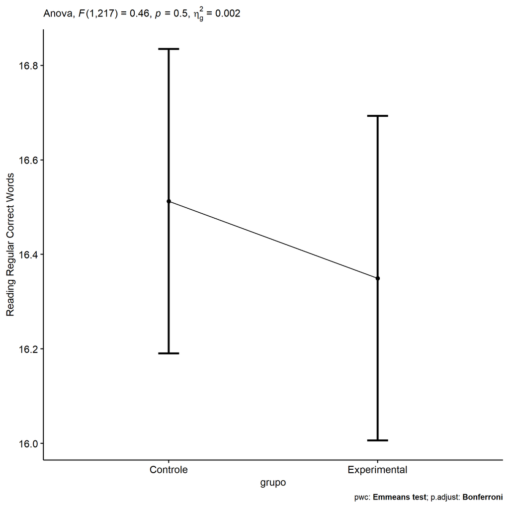

```r
if (!is.null(nrow(plots[["grupo"]]$data)))
  plots[["grupo"]] + ggplot2::ylab("Reading Regular Correct Words") +
  if (ymin.ci < ymax.ci) ggplot2::ylim(ymin.ci, ymax.ci)
```

```r
plots <- oneWayAncovaBoxPlots(
  wdat, "score.CR.pos", "grupo", aov, pwc, covar = "score.CR.pre",
  theme = "classic", color = color[["grupo"]],
  subtitle = which(aov$Effect == "grupo"))
```

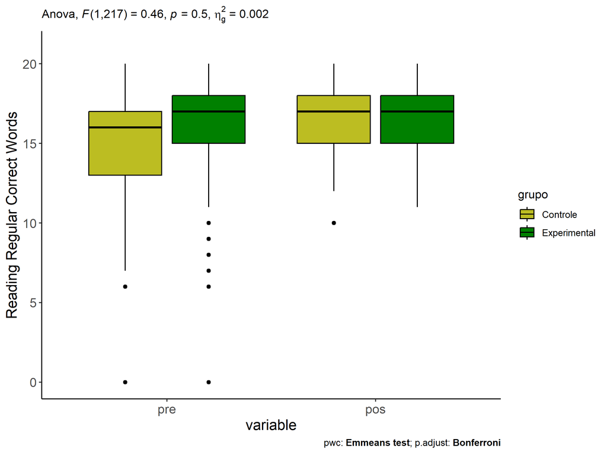

```r
if (length(unique(wdat[["grupo"]])) > 1)
  plots[["grupo"]] + ggplot2::ylab("Reading Regular Correct Words") +
  ggplot2::scale_x_discrete(labels=c('pre', 'pos')) +
  if (ymin < ymax) ggplot2::ylim(ymin, ymax)
```

```r
if (length(unique(wdat.long[["grupo"]])) > 1)
  plots <- oneWayAncovaBoxPlots(
    wdat.long, "score.CR", "grupo", aov, pwc.long,
    pre.post = "time", theme = "classic", color = color$prepost)
```

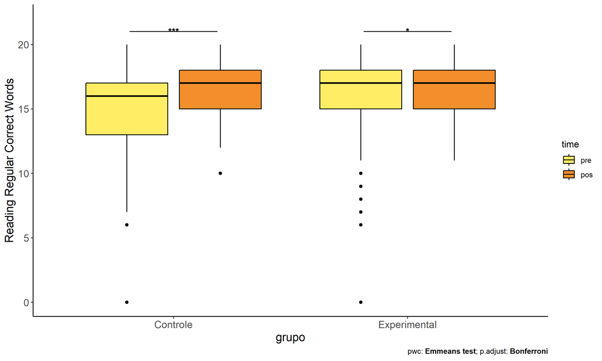

```r
if (length(unique(wdat.long[["grupo"]])) > 1)
  plots[["grupo"]] + ggplot2::ylab("Reading Regular Correct Words") +
  if (ymin < ymax) ggplot2::ylim(ymin, ymax)
```

### Checking linearity assumption

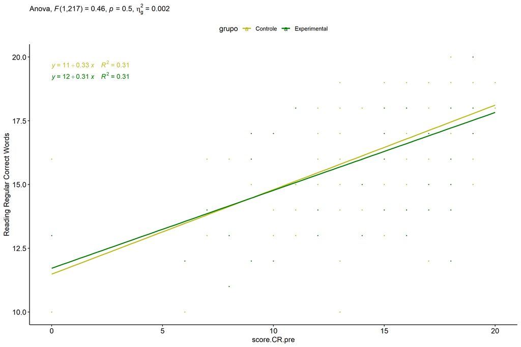

```r
ggscatter(wdat, x = "score.CR.pre", y = "score.CR.pos", size = 0.5,
          color = "grupo", add = "reg.line")+
  stat_regline_equation(
    aes(label =  paste(..eq.label.., ..rr.label.., sep = "~~~~"), color = grupo)
  ) +
  ggplot2::labs(subtitle = rstatix::get_test_label(aov, detailed = T, row = which(aov$Effect == "grupo"))) +
  ggplot2::scale_color_manual(values = color[["grupo"]]) +
  ggplot2::ylab("Reading Regular Correct Words")  +
  if (ymin < ymax) ggplot2::ylim(ymin, ymax)
```

### Checking normality and homogeneity

```r
res <- augment(lm(score.CR.pos ~ score.CR.pre + grupo, data = wdat))
```

```r
shapiro_test(res$.resid)
```

```
## # A tibble: 1 × 3
##   variable   statistic p.value
##   <chr>          <dbl>   <dbl>
## 1 res$.resid     0.984  0.0159
```

```r
levene_test(res, .resid ~ grupo)
```

```
## # A tibble: 1 × 4
##     df1   df2 statistic     p
##   <int> <int>     <dbl> <dbl>
## 1     1   218   0.00265 0.959
```

# ANCOVA and Pairwise for two factors **grupo:genero**

## Without remove non-normal data

```r
pdat = remove_group_data(dat[!is.na(dat[["grupo"]]) & !is.na(dat[["genero"]]),],
                         "score.CR.pos", c("grupo","genero"))
pdat = pdat[pdat[["genero"]] %in% do.call(
  intersect, lapply(unique(pdat[["grupo"]]), FUN = function(x) {
    unique(pdat[["genero"]][which(pdat[["grupo"]] == x)])
  })),]
pdat[["grupo"]] = factor(pdat[["grupo"]], level[["grupo"]])
pdat[["genero"]] = factor(
  pdat[["genero"]],
  level[["genero"]][level[["genero"]] %in% unique(pdat[["genero"]])])

pdat.long <- rbind(pdat[,c("id","grupo","genero")], pdat[,c("id","grupo","genero")])
pdat.long[["time"]] <- c(rep("pre", nrow(pdat)), rep("pos", nrow(pdat)))
pdat.long[["time"]] <- factor(pdat.long[["time"]], c("pre","pos"))
pdat.long[["score.CR"]] <- c(pdat[["score.CR.pre"]], pdat[["score.CR.pos"]])

if (length(unique(pdat[["genero"]])) >= 2) {
  aov = anova_test(pdat, score.CR.pos ~ score.CR.pre + grupo*genero)
  laov[["grupo:genero"]] <- get_anova_table(aov)
}
```

```r
if (length(unique(pdat[["genero"]])) >= 2) {
  pwcs <- list()
  pwcs[["genero"]] <- emmeans_test(
    group_by(pdat, grupo), score.CR.pos ~ genero,
    covariate = score.CR.pre, p.adjust.method = "bonferroni")
  pwcs[["grupo"]] <- emmeans_test(
    group_by(pdat, genero), score.CR.pos ~ grupo,
    covariate = score.CR.pre, p.adjust.method = "bonferroni")

  pwc <- plyr::rbind.fill(pwcs[["grupo"]], pwcs[["genero"]])
  pwc <- pwc[,c("grupo","genero", colnames(pwc)[!colnames(pwc) %in% c("grupo","genero")])]
}
```

```r
if (length(unique(pdat[["genero"]])) >= 2) {
  pwc.long <- emmeans_test(dplyr::group_by_at(pdat.long, c("grupo","genero")),
                           score.CR ~ time,
                           p.adjust.method = "bonferroni")
  lpwc[["grupo:genero"]] <- plyr::rbind.fill(pwc, pwc.long)
}
```

```r
if (length(unique(pdat[["genero"]])) >= 2) {
  ds <- get.descriptives(pdat, "score.CR.pos", c("grupo","genero"), covar = "score.CR.pre")
  ds <- merge(ds[ds$variable != "score.CR.pre",],
              ds[ds$variable == "score.CR.pre", !colnames(ds) %in% c("variable")],
              by = c("grupo","genero"), all.x = T, suffixes = c("", ".score.CR.pre"))
  ds <- merge(get_emmeans(pwcs[["grupo"]]), ds,
              by = c("grupo","genero"), suffixes = c(".emms", ""))
  ds <- ds[,c("grupo","genero","n","mean.score.CR.pre","se.score.CR.pre","mean","se",
              "emmean","se.emms","conf.low","conf.high")]

  colnames(ds) <- c("grupo","genero", "N", paste0(c("M","SE")," (pre)"),
                    paste0(c("M","SE"), " (unadj)"),
                    paste0(c("M", "SE"), " (adj)"), "conf.low", "conf.high")

  lemms[["grupo:genero"]] <- ds
}
```

## Computing ANCOVA and PairWise After removing non-normal data (OK)

```r
if (length(unique(pdat[["genero"]])) >= 2) {
  wdat = pdat

  res = residuals(lm(score.CR.pos ~ score.CR.pre + grupo*genero, data = wdat))
  non.normal = getNonNormal(res, wdat$id, plimit = 0.05)

  wdat = wdat[!wdat$id %in% non.normal,]

  wdat.long <- rbind(wdat[,c("id","grupo","genero")], wdat[,c("id","grupo","genero")])
  wdat.long[["time"]] <- c(rep("pre", nrow(wdat)), rep("pos", nrow(wdat)))
  wdat.long[["time"]] <- factor(wdat.long[["time"]], c("pre","pos"))
  wdat.long[["score.CR"]] <- c(wdat[["score.CR.pre"]], wdat[["score.CR.pos"]])


  ldat[["grupo:genero"]] = wdat

  (non.normal)
}
```

```
##  [1] "P356" "P312" "P195" "P17"  "P242" "P231" "P169" "P198" "P232" "P83"  "P79"  "P94"  "P117"
## [14] "P59"  "P294" "P46"  "P202" "P106" "P190" "P87"  "P5"   "P80"  "P12"  "P282" "P179" "P314"
## [27] "P103" "P305" "P300" "P128" "P68"  "P226" "P35"  "P364" "P307" "P119" "P286" "P214" "P308"
## [40] "P288" "P281" "P186" "P75"  "P121" "P22"  "P118" "P16"  "P216" "P306" "P330" "P274" "P332"
## [53] "P15"  "P146" "P205" "P289" "P370"
```

```r
if (length(unique(pdat[["genero"]])) >= 2) {
  aov = anova_test(wdat, score.CR.pos ~ score.CR.pre + grupo*genero)
  laov[["grupo:genero"]] <- merge(get_anova_table(aov), laov[["grupo:genero"]],
                                         by="Effect", suffixes = c("","'"))
  df = get_anova_table(aov)
}
```

| Effect | DFn | DFd | F | p | p<.05 | ges |
| --- | --- | --- | --- | --- | --- | --- |
| score.CR.pre | 1 | 248 | 84.526 | 0.000 | * | 0.254 |
| grupo | 1 | 248 | 1.573 | 0.211 |  | 0.006 |
| genero | 1 | 248 | 4.850 | 0.029 | * | 0.019 |
| grupo:genero | 1 | 248 | 0.638 | 0.425 |  | 0.003 |

```r
if (length(unique(pdat[["genero"]])) >= 2) {
  pwcs <- list()
  pwcs[["genero"]] <- emmeans_test(
    group_by(wdat, grupo), score.CR.pos ~ genero,
    covariate = score.CR.pre, p.adjust.method = "bonferroni")
  pwcs[["grupo"]] <- emmeans_test(
    group_by(wdat, genero), score.CR.pos ~ grupo,
    covariate = score.CR.pre, p.adjust.method = "bonferroni")

  pwc <- plyr::rbind.fill(pwcs[["grupo"]], pwcs[["genero"]])
  pwc <- pwc[,c("grupo","genero", colnames(pwc)[!colnames(pwc) %in% c("grupo","genero")])]
}
```

| grupo | genero | term | .y. | group1 | group2 | df | statistic | p | p.adj | p.adj.signif |
| --- | --- | --- | --- | --- | --- | --- | --- | --- | --- | --- |
|  | F | score.CR.pre*grupo | score.CR.pos | Controle | Experimental | 248 | -0.294 | 0.769 | 0.769 | ns |
|  | M | score.CR.pre*grupo | score.CR.pos | Controle | Experimental | 248 | -1.459 | 0.146 | 0.146 | ns |
| Controle |  | score.CR.pre*genero | score.CR.pos | F | M | 248 | 2.194 | 0.029 | 0.029 | * |
| Experimental |  | score.CR.pre*genero | score.CR.pos | F | M | 248 | 0.843 | 0.400 | 0.400 | ns |

```r
if (length(unique(pdat[["genero"]])) >= 2) {
  pwc.long <- emmeans_test(dplyr::group_by_at(wdat.long, c("grupo","genero")),
                           score.CR ~ time,
                           p.adjust.method = "bonferroni")
  lpwc[["grupo:genero"]] <- merge(plyr::rbind.fill(pwc, pwc.long),
                                         lpwc[["grupo:genero"]],
                                         by=c("grupo","genero","term",".y.","group1","group2"),
                                         suffixes = c("","'"))
}
```

| grupo | genero | term | .y. | group1 | group2 | df | statistic | p | p.adj | p.adj.signif |
| --- | --- | --- | --- | --- | --- | --- | --- | --- | --- | --- |
| Controle | F | time | score.CR | pre | pos | 498 | -2.483 | 0.013 | 0.013 | * |
| Controle | M | time | score.CR | pre | pos | 498 | -1.486 | 0.138 | 0.138 | ns |
| Experimental | F | time | score.CR | pre | pos | 498 | -0.517 | 0.605 | 0.605 | ns |
| Experimental | M | time | score.CR | pre | pos | 498 | -2.082 | 0.038 | 0.038 | * |

```r
if (length(unique(pdat[["genero"]])) >= 2) {
  ds <- get.descriptives(wdat, "score.CR.pos", c("grupo","genero"), covar = "score.CR.pre")
  ds <- merge(ds[ds$variable != "score.CR.pre",],
              ds[ds$variable == "score.CR.pre", !colnames(ds) %in% c("variable")],
              by = c("grupo","genero"), all.x = T, suffixes = c("", ".score.CR.pre"))
  ds <- merge(get_emmeans(pwcs[["grupo"]]), ds,
              by = c("grupo","genero"), suffixes = c(".emms", ""))
  ds <- ds[,c("grupo","genero","n","mean.score.CR.pre","se.score.CR.pre",
              "mean","se","emmean","se.emms","conf.low","conf.high")]

  colnames(ds) <- c("grupo","genero", "N", paste0(c("M","SE")," (pre)"),
                    paste0(c("M","SE"), " (unadj)"),
                    paste0(c("M", "SE"), " (adj)"), "conf.low", "conf.high")

  lemms[["grupo:genero"]] <- merge(ds, lemms[["grupo:genero"]],
                                          by=c("grupo","genero"), suffixes = c("","'"))
}
```

| grupo | genero | N | M (pre) | SE (pre) | M (unadj) | SE (unadj) | M (adj) | SE (adj) | conf.low | conf.high |
| --- | --- | --- | --- | --- | --- | --- | --- | --- | --- | --- |
| Controle | F | 75 | 14.640 | 0.450 | 15.973 | 0.299 | 16.019 | 0.272 | 15.485 | 16.554 |
| Controle | M | 68 | 14.059 | 0.433 | 14.897 | 0.398 | 15.154 | 0.286 | 14.590 | 15.718 |
| Experimental | F | 50 | 16.400 | 0.395 | 16.740 | 0.311 | 16.147 | 0.339 | 15.480 | 16.814 |
| Experimental | M | 60 | 14.367 | 0.579 | 15.617 | 0.329 | 15.762 | 0.304 | 15.163 | 16.361 |

### Plots for ancova

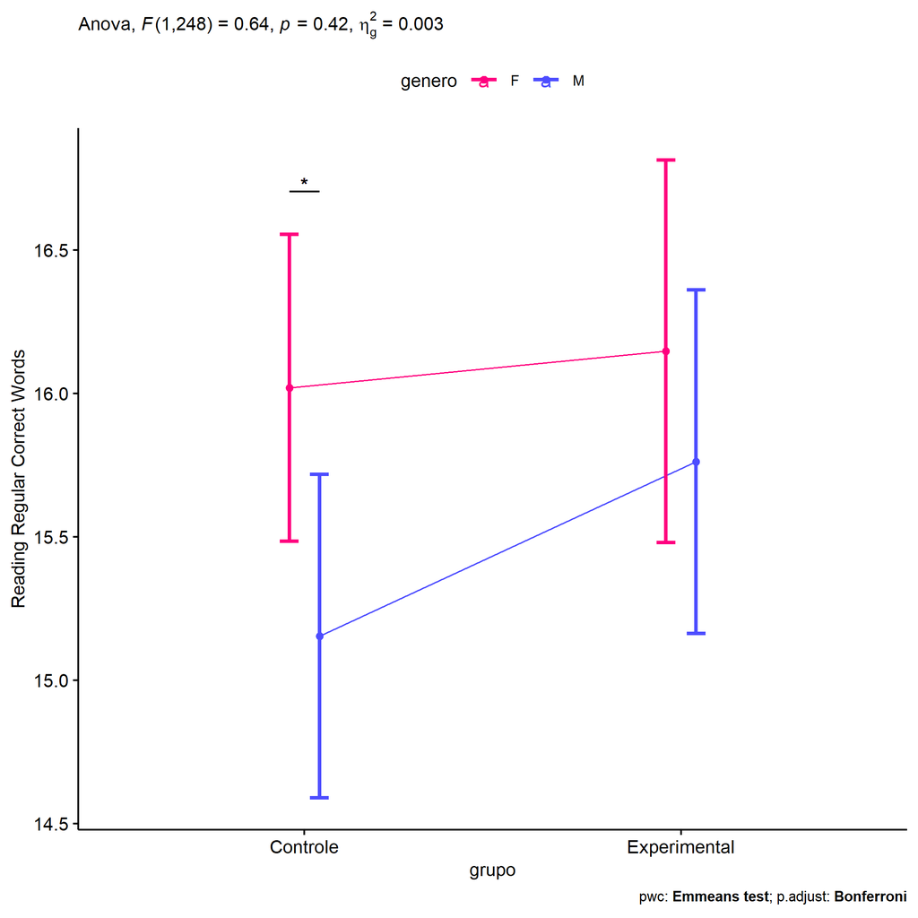

```r
if (length(unique(pdat[["genero"]])) >= 2) {
  ggPlotAoC2(pwcs, "grupo", "genero", aov, ylab = "Reading Regular Correct Words",
             subtitle = which(aov$Effect == "grupo:genero"), addParam = "errorbar") +
    ggplot2::scale_color_manual(values = color[["genero"]]) +
    ggplot2::ylab("Reading Regular Correct Words") +
    if (ymin.ci < ymax.ci) ggplot2::ylim(ymin.ci, ymax.ci)
}
```

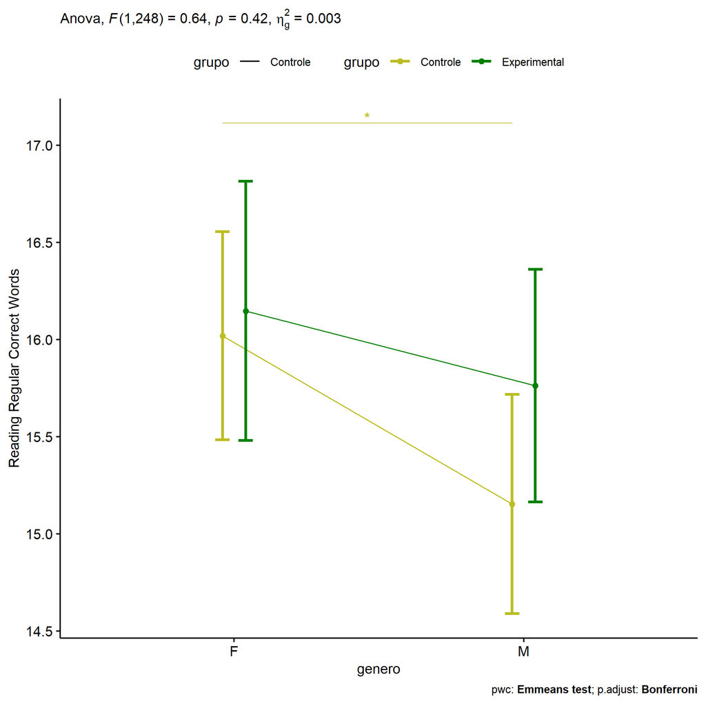

```r
if (length(unique(pdat[["genero"]])) >= 2) {
  ggPlotAoC2(pwcs, "genero", "grupo", aov, ylab = "Reading Regular Correct Words",
               subtitle = which(aov$Effect == "grupo:genero"), addParam = "errorbar") +
    ggplot2::scale_color_manual(values = color[["grupo"]]) +
    ggplot2::ylab("Reading Regular Correct Words") +
    if (ymin.ci < ymax.ci) ggplot2::ylim(ymin.ci, ymax.ci)
}
```

```r
if (length(unique(pdat[["genero"]])) >= 2) {
  plots <- twoWayAncovaBoxPlots(
    wdat, "score.CR.pos", c("grupo","genero"), aov, pwcs, covar = "score.CR.pre",
    theme = "classic", color = color[["grupo:genero"]],
    subtitle = which(aov$Effect == "grupo:genero"))
}
```

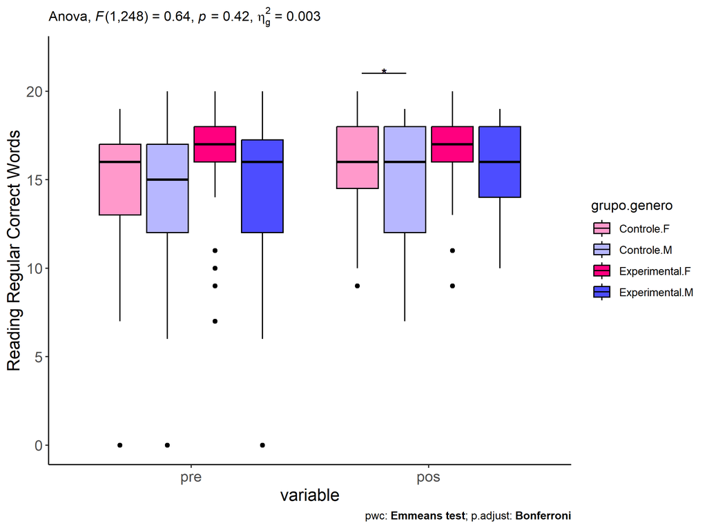

```r
if (length(unique(pdat[["genero"]])) >= 2) {
  plots[["grupo:genero"]] + ggplot2::ylab("Reading Regular Correct Words") +
  ggplot2::scale_x_discrete(labels=c('pre', 'pos')) +
  if (ymin < ymax) ggplot2::ylim(ymin, ymax)
}
```

```r
if (length(unique(pdat[["genero"]])) >= 2) {
  plots <- twoWayAncovaBoxPlots(
    wdat.long, "score.CR", c("grupo","genero"), aov, pwc.long,
    pre.post = "time",
    theme = "classic", color = color$prepost)
}
```

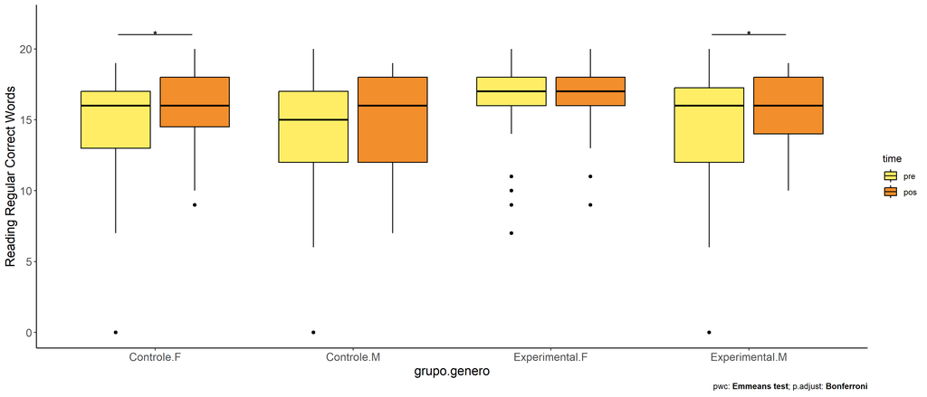

```r
if (length(unique(pdat[["genero"]])) >= 2)
  plots[["grupo:genero"]] + ggplot2::ylab("Reading Regular Correct Words") +
    if (ymin < ymax) ggplot2::ylim(ymin, ymax)
```

### Checking linearity assumption

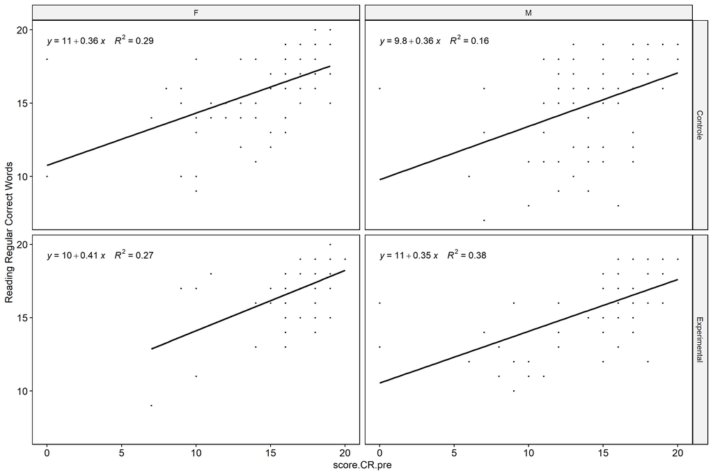

```r
if (length(unique(pdat[["genero"]])) >= 2) {
  ggscatter(wdat, x = "score.CR.pre", y = "score.CR.pos", size = 0.5,
            facet.by = c("grupo","genero"), add = "reg.line")+
    stat_regline_equation(
      aes(label =  paste(..eq.label.., ..rr.label.., sep = "~~~~"))
    ) + ggplot2::ylab("Reading Regular Correct Words") +
    if (ymin < ymax) ggplot2::ylim(ymin, ymax)
}
```

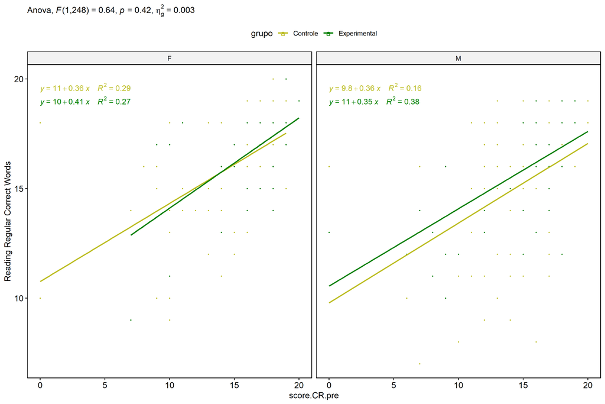

```r
if (length(unique(pdat[["genero"]])) >= 2) {
  ggscatter(wdat, x = "score.CR.pre", y = "score.CR.pos", size = 0.5,
            color = "grupo", facet.by = "genero", add = "reg.line")+
    stat_regline_equation(
      aes(label =  paste(..eq.label.., ..rr.label.., sep = "~~~~"), color = grupo)
    ) +
    ggplot2::labs(subtitle = rstatix::get_test_label(aov, detailed = T, row = which(aov$Effect == "grupo:genero"))) +
    ggplot2::scale_color_manual(values = color[["grupo"]]) +
    ggplot2::ylab("Reading Regular Correct Words") +
    if (ymin < ymax) ggplot2::ylim(ymin, ymax)
}
```

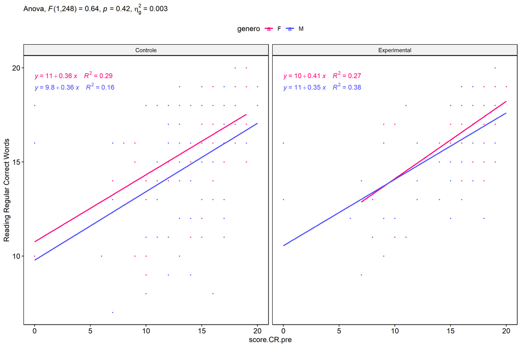

```r
if (length(unique(pdat[["genero"]])) >= 2) {
  ggscatter(wdat, x = "score.CR.pre", y = "score.CR.pos", size = 0.5,
            color = "genero", facet.by = "grupo", add = "reg.line")+
    stat_regline_equation(
      aes(label =  paste(..eq.label.., ..rr.label.., sep = "~~~~"), color = genero)
    ) +
    ggplot2::labs(subtitle = rstatix::get_test_label(aov, detailed = T, row = which(aov$Effect == "grupo:genero"))) +
    ggplot2::scale_color_manual(values = color[["genero"]]) +
    ggplot2::ylab("Reading Regular Correct Words") +
    if (ymin < ymax) ggplot2::ylim(ymin, ymax)
}
```

### Checking normality and homogeneity

```r
if (length(unique(pdat[["genero"]])) >= 2)
  res <- augment(lm(score.CR.pos ~ score.CR.pre + grupo*genero, data = wdat))
```

```r
if (length(unique(pdat[["genero"]])) >= 2)
  shapiro_test(res$.resid)
```

```
## # A tibble: 1 × 3
##   variable   statistic p.value
##   <chr>          <dbl>   <dbl>
## 1 res$.resid     0.983 0.00353
```

```r
if (length(unique(pdat[["genero"]])) >= 2)
  levene_test(res, .resid ~ grupo*genero)
```

```
## # A tibble: 1 × 4
##     df1   df2 statistic       p
##   <int> <int>     <dbl>   <dbl>
## 1     3   249      5.11 0.00191
```

# ANCOVA and Pairwise for two factors **grupo:zona.participante**

## Without remove non-normal data

```r
pdat = remove_group_data(dat[!is.na(dat[["grupo"]]) & !is.na(dat[["zona.participante"]]),],
                         "score.CR.pos", c("grupo","zona.participante"))
pdat = pdat[pdat[["zona.participante"]] %in% do.call(
  intersect, lapply(unique(pdat[["grupo"]]), FUN = function(x) {
    unique(pdat[["zona.participante"]][which(pdat[["grupo"]] == x)])
  })),]
pdat[["grupo"]] = factor(pdat[["grupo"]], level[["grupo"]])
pdat[["zona.participante"]] = factor(
  pdat[["zona.participante"]],
  level[["zona.participante"]][level[["zona.participante"]] %in% unique(pdat[["zona.participante"]])])

pdat.long <- rbind(pdat[,c("id","grupo","zona.participante")], pdat[,c("id","grupo","zona.participante")])
pdat.long[["time"]] <- c(rep("pre", nrow(pdat)), rep("pos", nrow(pdat)))
pdat.long[["time"]] <- factor(pdat.long[["time"]], c("pre","pos"))
pdat.long[["score.CR"]] <- c(pdat[["score.CR.pre"]], pdat[["score.CR.pos"]])

if (length(unique(pdat[["zona.participante"]])) >= 2) {
  aov = anova_test(pdat, score.CR.pos ~ score.CR.pre + grupo*zona.participante)
  laov[["grupo:zona.participante"]] <- get_anova_table(aov)
}
```

```r
if (length(unique(pdat[["zona.participante"]])) >= 2) {
  pwcs <- list()
  pwcs[["zona.participante"]] <- emmeans_test(
    group_by(pdat, grupo), score.CR.pos ~ zona.participante,
    covariate = score.CR.pre, p.adjust.method = "bonferroni")
  pwcs[["grupo"]] <- emmeans_test(
    group_by(pdat, zona.participante), score.CR.pos ~ grupo,
    covariate = score.CR.pre, p.adjust.method = "bonferroni")

  pwc <- plyr::rbind.fill(pwcs[["grupo"]], pwcs[["zona.participante"]])
  pwc <- pwc[,c("grupo","zona.participante", colnames(pwc)[!colnames(pwc) %in% c("grupo","zona.participante")])]
}
```

```r
if (length(unique(pdat[["zona.participante"]])) >= 2) {
  pwc.long <- emmeans_test(dplyr::group_by_at(pdat.long, c("grupo","zona.participante")),
                           score.CR ~ time,
                           p.adjust.method = "bonferroni")
  lpwc[["grupo:zona.participante"]] <- plyr::rbind.fill(pwc, pwc.long)
}
```

```r
if (length(unique(pdat[["zona.participante"]])) >= 2) {
  ds <- get.descriptives(pdat, "score.CR.pos", c("grupo","zona.participante"), covar = "score.CR.pre")
  ds <- merge(ds[ds$variable != "score.CR.pre",],
              ds[ds$variable == "score.CR.pre", !colnames(ds) %in% c("variable")],
              by = c("grupo","zona.participante"), all.x = T, suffixes = c("", ".score.CR.pre"))
  ds <- merge(get_emmeans(pwcs[["grupo"]]), ds,
              by = c("grupo","zona.participante"), suffixes = c(".emms", ""))
  ds <- ds[,c("grupo","zona.participante","n","mean.score.CR.pre","se.score.CR.pre","mean","se",
              "emmean","se.emms","conf.low","conf.high")]

  colnames(ds) <- c("grupo","zona.participante", "N", paste0(c("M","SE")," (pre)"),
                    paste0(c("M","SE"), " (unadj)"),
                    paste0(c("M", "SE"), " (adj)"), "conf.low", "conf.high")

  lemms[["grupo:zona.participante"]] <- ds
}
```

## Computing ANCOVA and PairWise After removing non-normal data (OK)

```r
if (length(unique(pdat[["zona.participante"]])) >= 2) {
  wdat = pdat

  res = residuals(lm(score.CR.pos ~ score.CR.pre + grupo*zona.participante, data = wdat))
  non.normal = getNonNormal(res, wdat$id, plimit = 0.05)

  wdat = wdat[!wdat$id %in% non.normal,]

  wdat.long <- rbind(wdat[,c("id","grupo","zona.participante")], wdat[,c("id","grupo","zona.participante")])
  wdat.long[["time"]] <- c(rep("pre", nrow(wdat)), rep("pos", nrow(wdat)))
  wdat.long[["time"]] <- factor(wdat.long[["time"]], c("pre","pos"))
  wdat.long[["score.CR"]] <- c(wdat[["score.CR.pre"]], wdat[["score.CR.pos"]])


  ldat[["grupo:zona.participante"]] = wdat

  (non.normal)
}
```

```
##   [1] "P169" "P294" "P83"  "P282" "P80"  "P117" "P46"  "P87"  "P356" "P106" "P79"  "P198" "P94"
##  [14] "P5"   "P195" "P128" "P68"  "P226" "P229" "P307" "P308" "P75"  "P186" "P286" "P35"  "P330"
##  [27] "P364" "P370" "P283" "P288" "P144" "P64"  "P354" "P163" "P173" "P289" "P136" "P277" "P164"
##  [40] "P187" "P181" "P281" "P290" "P306" "P134" "P332" "P132" "P131" "P371" "P368" "P295" "P82"
##  [53] "P170" "P99"  "P88"  "P115" "P67"  "P357" "P355" "P10"  "P125" "P107" "P160" "P374" "P352"
##  [66] "P268" "P86"  "P192" "P329" "P225" "P228" "P180" "P154" "P143" "P108" "P70"  "P162" "P133"
##  [79] "P373" "P34"  "P369" "P191" "P145" "P101" "P275" "P71"  "P156" "P309" "P114" "P235" "P153"
##  [92] "P246" "P24"  "P334" "P338" "P274" "P321" "P323" "P112" "P95"  "P184" "P188" "P147" "P77"
## [105] "P25"  "P41"  "P4"   "P113" "P129" "P331" "P310" "P91"  "P149" "P111" "P171" "P182" "P217"
## [118] "P138" "P38"  "P8"   "P322" "P302" "P96"  "P37"  "P65"  "P177" "P148" "P224" "P363" "P343"
## [131] "P141" "P303" "P69"  "P161" "P168" "P215" "P223" "P276" "P366" "P257" "P326" "P189" "P90"
## [144] "P158" "P367" "P42"  "P337" "P342" "P152" "P318" "P285" "P350" "P1"   "P221" "P159" "P140"
## [157] "P33"  "P319" "P333" "P178" "P183" "P284" "P287" "P11"  "P176" "P220" "P9"   "P19"  "P280"
## [170] "P73"  "P351" "P348" "P15"  "P315" "P279" "P344" "P360" "P359" "P175" "P150" "P194" "P139"
## [183] "P130" "P142" "P216" "P327"
```

```r
if (length(unique(pdat[["zona.participante"]])) >= 2) {
  aov = anova_test(wdat, score.CR.pos ~ score.CR.pre + grupo*zona.participante)
  laov[["grupo:zona.participante"]] <- merge(get_anova_table(aov), laov[["grupo:zona.participante"]],
                                         by="Effect", suffixes = c("","'"))
  df = get_anova_table(aov)
}
```

| Effect | DFn | DFd | F | p | p<.05 | ges |
| --- | --- | --- | --- | --- | --- | --- |
| score.CR.pre | 1 | 43 | 57.007 | 0.000 | * | 0.570 |
| grupo | 1 | 43 | 4.972 | 0.031 | * | 0.104 |
| zona.participante | 1 | 43 | 14.381 | 0.000 | * | 0.251 |
| grupo:zona.participante | 1 | 43 | 0.021 | 0.885 |  | 0.000 |

```r
if (length(unique(pdat[["zona.participante"]])) >= 2) {
  pwcs <- list()
  pwcs[["zona.participante"]] <- emmeans_test(
    group_by(wdat, grupo), score.CR.pos ~ zona.participante,
    covariate = score.CR.pre, p.adjust.method = "bonferroni")
  pwcs[["grupo"]] <- emmeans_test(
    group_by(wdat, zona.participante), score.CR.pos ~ grupo,
    covariate = score.CR.pre, p.adjust.method = "bonferroni")

  pwc <- plyr::rbind.fill(pwcs[["grupo"]], pwcs[["zona.participante"]])
  pwc <- pwc[,c("grupo","zona.participante", colnames(pwc)[!colnames(pwc) %in% c("grupo","zona.participante")])]
}
```

| grupo | zona.participante | term | .y. | group1 | group2 | df | statistic | p | p.adj | p.adj.signif |
| --- | --- | --- | --- | --- | --- | --- | --- | --- | --- | --- |
|  | Rural | score.CR.pre*grupo | score.CR.pos | Controle | Experimental | 43 | -1.852 | 0.071 | 0.071 | ns |
|  | Urbana | score.CR.pre*grupo | score.CR.pos | Controle | Experimental | 43 | -1.243 | 0.221 | 0.221 | ns |
| Controle |  | score.CR.pre*zona.participante | score.CR.pos | Rural | Urbana | 43 | 2.635 | 0.012 | 0.012 | * |
| Experimental |  | score.CR.pre*zona.participante | score.CR.pos | Rural | Urbana | 43 | 2.769 | 0.008 | 0.008 | ** |

```r
if (length(unique(pdat[["zona.participante"]])) >= 2) {
  pwc.long <- emmeans_test(dplyr::group_by_at(wdat.long, c("grupo","zona.participante")),
                           score.CR ~ time,
                           p.adjust.method = "bonferroni")
  lpwc[["grupo:zona.participante"]] <- merge(plyr::rbind.fill(pwc, pwc.long),
                                         lpwc[["grupo:zona.participante"]],
                                         by=c("grupo","zona.participante","term",".y.","group1","group2"),
                                         suffixes = c("","'"))
}
```

| grupo | zona.participante | term | .y. | group1 | group2 | df | statistic | p | p.adj | p.adj.signif |
| --- | --- | --- | --- | --- | --- | --- | --- | --- | --- | --- |
| Controle | Rural | time | score.CR | pre | pos | 88 | 1.729 | 0.087 | 0.087 | ns |
| Controle | Urbana | time | score.CR | pre | pos | 88 | 1.637 | 0.105 | 0.105 | ns |
| Experimental | Rural | time | score.CR | pre | pos | 88 | 0.712 | 0.479 | 0.479 | ns |
| Experimental | Urbana | time | score.CR | pre | pos | 88 | 1.281 | 0.204 | 0.204 | ns |

```r
if (length(unique(pdat[["zona.participante"]])) >= 2) {
  ds <- get.descriptives(wdat, "score.CR.pos", c("grupo","zona.participante"), covar = "score.CR.pre")
  ds <- merge(ds[ds$variable != "score.CR.pre",],
              ds[ds$variable == "score.CR.pre", !colnames(ds) %in% c("variable")],
              by = c("grupo","zona.participante"), all.x = T, suffixes = c("", ".score.CR.pre"))
  ds <- merge(get_emmeans(pwcs[["grupo"]]), ds,
              by = c("grupo","zona.participante"), suffixes = c(".emms", ""))
  ds <- ds[,c("grupo","zona.participante","n","mean.score.CR.pre","se.score.CR.pre",
              "mean","se","emmean","se.emms","conf.low","conf.high")]

  colnames(ds) <- c("grupo","zona.participante", "N", paste0(c("M","SE")," (pre)"),
                    paste0(c("M","SE"), " (unadj)"),
                    paste0(c("M", "SE"), " (adj)"), "conf.low", "conf.high")

  lemms[["grupo:zona.participante"]] <- merge(ds, lemms[["grupo:zona.participante"]],
                                          by=c("grupo","zona.participante"), suffixes = c("","'"))
}
```

| grupo | zona.participante | N | M (pre) | SE (pre) | M (unadj) | SE (unadj) | M (adj) | SE (adj) | conf.low | conf.high |
| --- | --- | --- | --- | --- | --- | --- | --- | --- | --- | --- |
| Controle | Rural | 14 | 14.643 | 0.617 | 12.857 | 0.443 | 12.551 | 0.329 | 11.888 | 13.215 |
| Controle | Urbana | 10 | 12.700 | 1.106 | 10.700 | 0.539 | 11.190 | 0.392 | 10.399 | 11.980 |
| Experimental | Rural | 16 | 14.188 | 0.927 | 13.500 | 0.500 | 13.381 | 0.306 | 12.764 | 13.997 |
| Experimental | Urbana | 8 | 13.500 | 1.476 | 11.750 | 0.701 | 11.912 | 0.433 | 11.040 | 12.784 |

### Plots for ancova

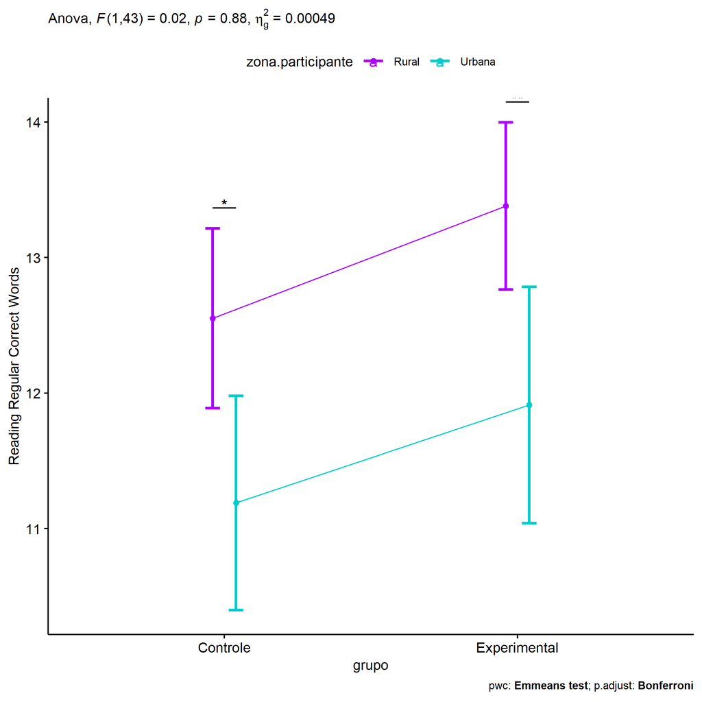

```r
if (length(unique(pdat[["zona.participante"]])) >= 2) {
  ggPlotAoC2(pwcs, "grupo", "zona.participante", aov, ylab = "Reading Regular Correct Words",
             subtitle = which(aov$Effect == "grupo:zona.participante"), addParam = "errorbar") +
    ggplot2::scale_color_manual(values = color[["zona.participante"]]) +
    ggplot2::ylab("Reading Regular Correct Words") +
    if (ymin.ci < ymax.ci) ggplot2::ylim(ymin.ci, ymax.ci)
}
```

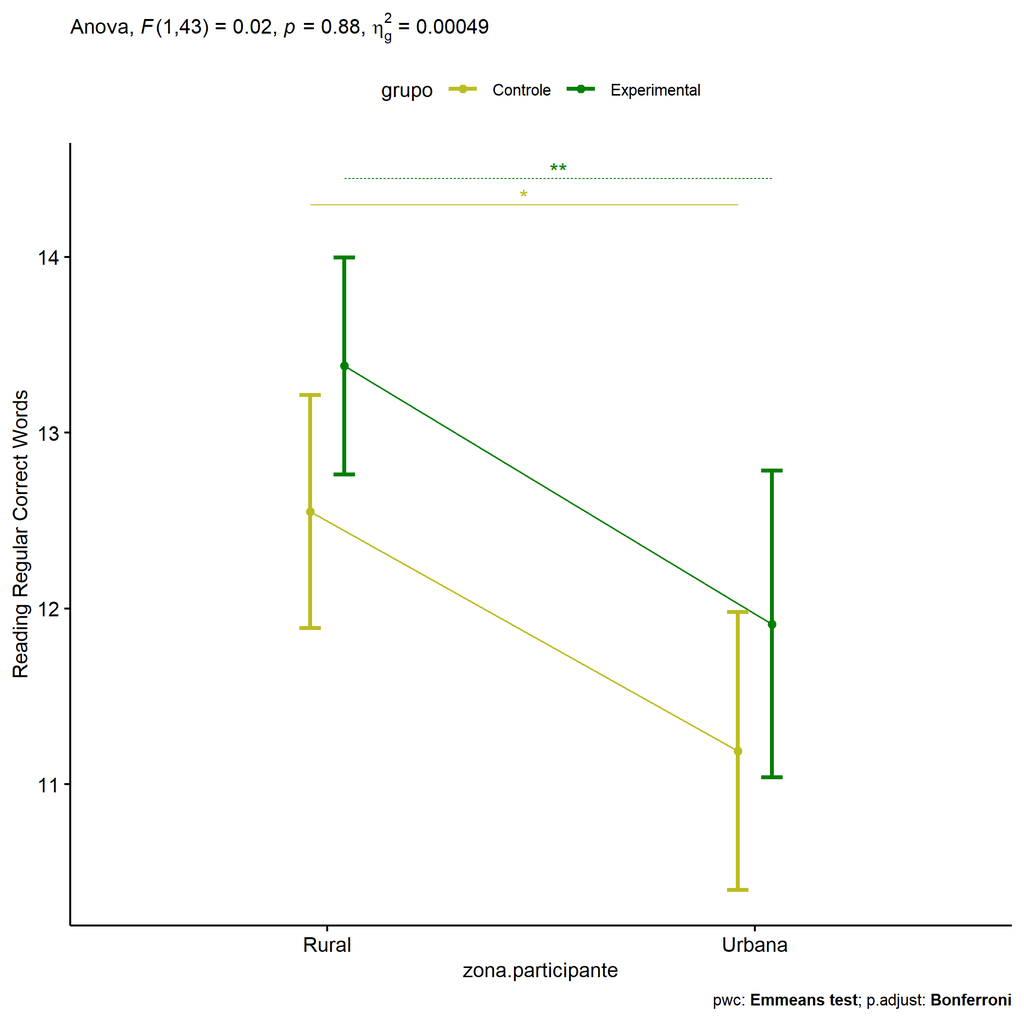

```r
if (length(unique(pdat[["zona.participante"]])) >= 2) {
  ggPlotAoC2(pwcs, "zona.participante", "grupo", aov, ylab = "Reading Regular Correct Words",
               subtitle = which(aov$Effect == "grupo:zona.participante"), addParam = "errorbar") +
    ggplot2::scale_color_manual(values = color[["grupo"]]) +
    ggplot2::ylab("Reading Regular Correct Words") +
    if (ymin.ci < ymax.ci) ggplot2::ylim(ymin.ci, ymax.ci)
}
```

```r
if (length(unique(pdat[["zona.participante"]])) >= 2) {
  plots <- twoWayAncovaBoxPlots(
    wdat, "score.CR.pos", c("grupo","zona.participante"), aov, pwcs, covar = "score.CR.pre",
    theme = "classic", color = color[["grupo:zona.participante"]],
    subtitle = which(aov$Effect == "grupo:zona.participante"))
}
```

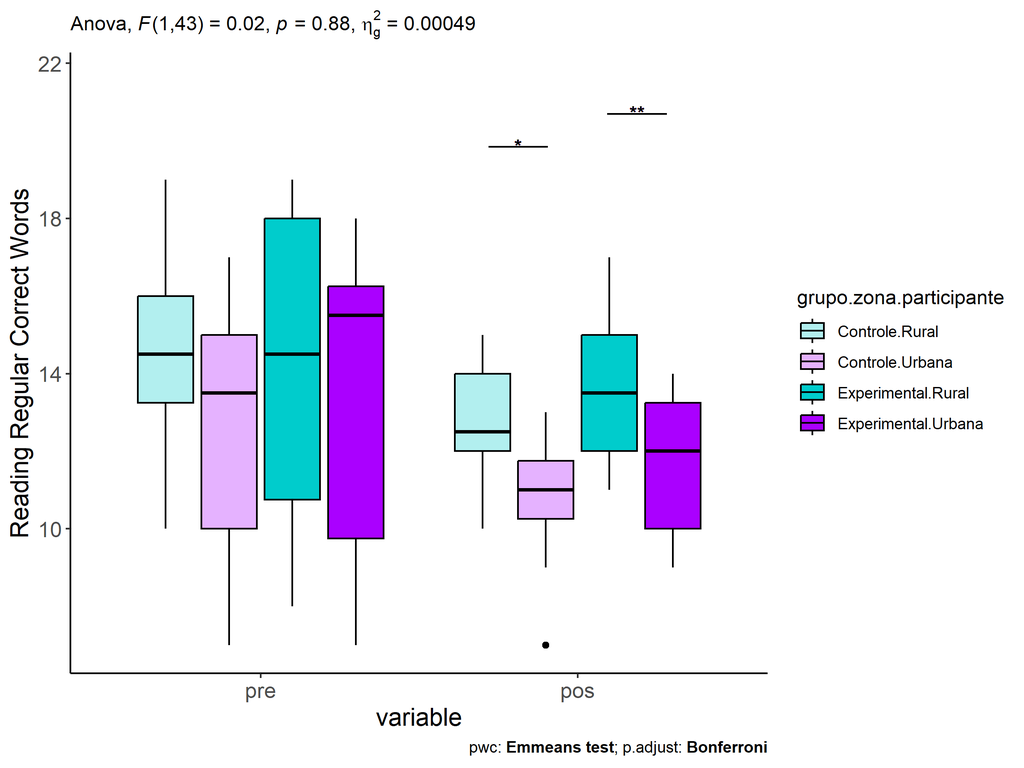

```r
if (length(unique(pdat[["zona.participante"]])) >= 2) {
  plots[["grupo:zona.participante"]] + ggplot2::ylab("Reading Regular Correct Words") +
  ggplot2::scale_x_discrete(labels=c('pre', 'pos')) +
  if (ymin < ymax) ggplot2::ylim(ymin, ymax)
}
```

```r
if (length(unique(pdat[["zona.participante"]])) >= 2) {
  plots <- twoWayAncovaBoxPlots(
    wdat.long, "score.CR", c("grupo","zona.participante"), aov, pwc.long,
    pre.post = "time",
    theme = "classic", color = color$prepost)
}
```

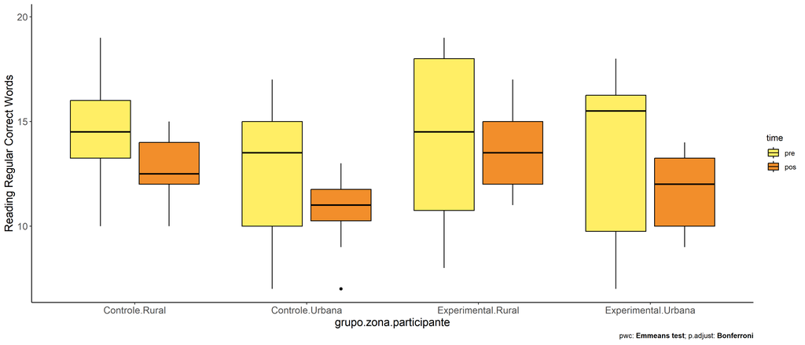

```r
if (length(unique(pdat[["zona.participante"]])) >= 2)
  plots[["grupo:zona.participante"]] + ggplot2::ylab("Reading Regular Correct Words") +
    if (ymin < ymax) ggplot2::ylim(ymin, ymax)
```

### Checking linearity assumption

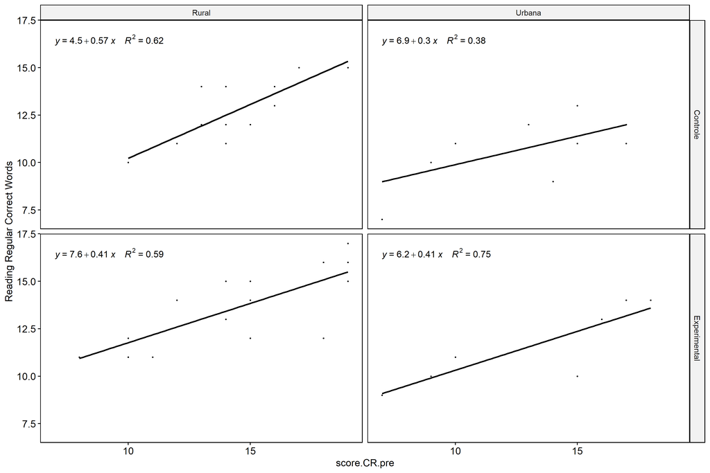

```r
if (length(unique(pdat[["zona.participante"]])) >= 2) {
  ggscatter(wdat, x = "score.CR.pre", y = "score.CR.pos", size = 0.5,
            facet.by = c("grupo","zona.participante"), add = "reg.line")+
    stat_regline_equation(
      aes(label =  paste(..eq.label.., ..rr.label.., sep = "~~~~"))
    ) + ggplot2::ylab("Reading Regular Correct Words") +
    if (ymin < ymax) ggplot2::ylim(ymin, ymax)
}
```

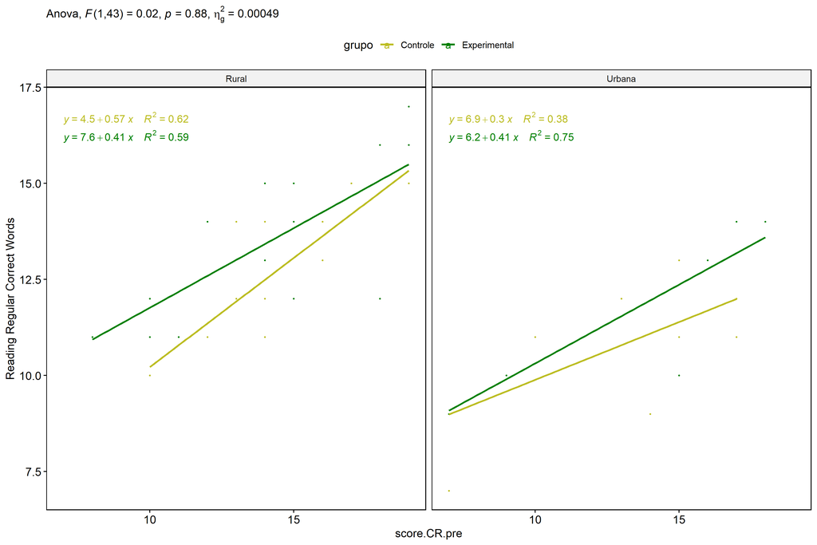

```r
if (length(unique(pdat[["zona.participante"]])) >= 2) {
  ggscatter(wdat, x = "score.CR.pre", y = "score.CR.pos", size = 0.5,
            color = "grupo", facet.by = "zona.participante", add = "reg.line")+
    stat_regline_equation(
      aes(label =  paste(..eq.label.., ..rr.label.., sep = "~~~~"), color = grupo)
    ) +
    ggplot2::labs(subtitle = rstatix::get_test_label(aov, detailed = T, row = which(aov$Effect == "grupo:zona.participante"))) +
    ggplot2::scale_color_manual(values = color[["grupo"]]) +
    ggplot2::ylab("Reading Regular Correct Words") +
    if (ymin < ymax) ggplot2::ylim(ymin, ymax)
}
```

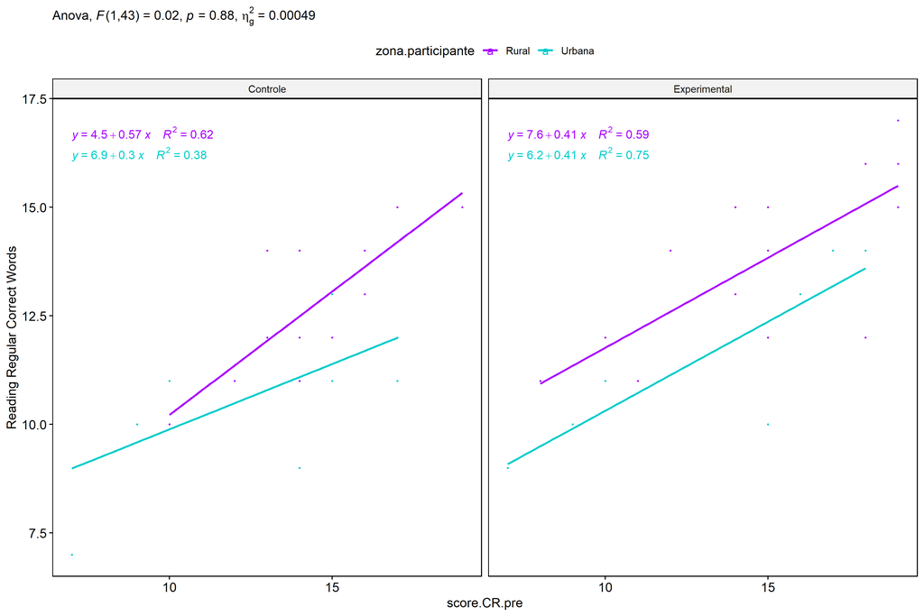

```r
if (length(unique(pdat[["zona.participante"]])) >= 2) {
  ggscatter(wdat, x = "score.CR.pre", y = "score.CR.pos", size = 0.5,
            color = "zona.participante", facet.by = "grupo", add = "reg.line")+
    stat_regline_equation(
      aes(label =  paste(..eq.label.., ..rr.label.., sep = "~~~~"), color = zona.participante)
    ) +
    ggplot2::labs(subtitle = rstatix::get_test_label(aov, detailed = T, row = which(aov$Effect == "grupo:zona.participante"))) +
    ggplot2::scale_color_manual(values = color[["zona.participante"]]) +
    ggplot2::ylab("Reading Regular Correct Words") +
    if (ymin < ymax) ggplot2::ylim(ymin, ymax)
}
```